# SPPH 504 Section 007 Lab 6 (part 1) Missing data and Imputation

### 2.2.3 Stochastic regression imputation

- Ref: (Van Buuren 2018), Section 1.3.5
- One disadvantage to regression imputation is that it used the fitted model without error terms. Therefore, the imputed results are too close to the regression line and biased the correlations, reduced the variance of the data.
- Stochastic regression corrected this problem by adding a error term when imputing the values, which potentially better reflect the correlations between variables

```r
imputation3 <- mice(nhanes, method = "norm.nob", # stochastic regression imputation
                    m = 1, maxit = 1,
                    seed = 504, print = FALSE)
mice::complete(imputation3)
```

```
##    age      bmi       hyp      chl
## 1    1 30.89870 0.5344772 169.9860
## 2    2 22.70000 1.0000000 187.0000
## 3    1 26.73817 1.0000000 187.0000
## 4    3 19.88515 1.5733697 228.9288
## 5    1 20.40000 1.0000000 113.0000
## 6    3 20.05549 1.6280690 184.0000
## 7    1 22.50000 1.0000000 118.0000
## 8    1 30.10000 1.0000000 187.0000
## 9    2 22.00000 1.0000000 238.0000
## 10   2 20.85410 1.1999144 145.7660
## 11   1 31.12587 1.4352616 266.0222
## 12   2 37.88203 1.5771787 293.5844
## 13   3 21.70000 1.0000000 206.0000
## 14   2 28.70000 2.0000000 204.0000
## 15   1 29.60000 1.0000000 153.2928
## 16   1 25.88327 1.1490993 181.2275
## 17   3 27.20000 2.0000000 284.0000
## 18   2 26.30000 2.0000000 199.0000
## 19   1 35.30000 1.0000000 218.0000
## 20   3 25.50000 2.0000000 198.0529
## 21   1 28.40046 1.0787988 148.3397
## 22   1 33.20000 1.0000000 229.0000
## 23   1 27.50000 1.0000000 131.0000
## 24   3 24.90000 1.0000000 219.3886
## 25   2 27.40000 1.0000000 186.0000
```

```r
# examine the correlation between age and bmi before and after imputation
fit1 <- lm(age ~ bmi, nhanes)
fit3 <- lm(age ~ bmi, mice::complete(imputation3))
summary(fit1)
```

```
##
## Call:
## lm(formula = age ~ bmi, data = nhanes)
##
## Residuals:
##     Min      1Q  Median      3Q     Max
## -1.2660 -0.5614 -0.1225  0.4660  1.2344
##
## Coefficients:
##             Estimate Std. Error t value Pr(>|t|)
## (Intercept)  3.76718    1.31945   2.855   0.0127 *
## bmi         -0.07359    0.04910  -1.499   0.1561
## ---
## Signif. codes:  0 '***' 0.001 '**' 0.01 '*' 0.05 '.' 0.1 ' ' 1
##
## Residual standard error: 0.8015 on 14 degrees of freedom
##   (9 observations deleted due to missingness)
## Multiple R-squared:  0.1383, Adjusted R-squared:  0.07672
## F-statistic: 2.246 on 1 and 14 DF,  p-value: 0.1561
```

```r
summary(fit3)
```

```
##
## Call:
## lm(formula = age ~ bmi, data = mice::complete(imputation3))
##
## Residuals:
##     Min      1Q  Median      3Q     Max
## -1.2368 -0.5371 -0.1151  0.7240  1.2804
##
## Coefficients:
##             Estimate Std. Error t value Pr(>|t|)
## (Intercept)  3.78835    0.87353   4.337 0.000243 ***
## bmi         -0.07606    0.03225  -2.358 0.027244 *
## ---
## Signif. codes:  0 '***' 0.001 '**' 0.01 '*' 0.05 '.' 0.1 ' ' 1
##
## Residual standard error: 0.7615 on 23 degrees of freedom
## Multiple R-squared:  0.1947, Adjusted R-squared:  0.1597
## F-statistic: 5.561 on 1 and 23 DF,  p-value: 0.02724
```

```r
## Fitted coefficients of bmi are much closer before and after imputation
with(data=nhanes, cor(age, bmi, use = "complete.obs"))
```

```
## [1] -0.3718535
```

```r
with(data=nhanes, cor(age, bmi, use = "pairwise.complete.obs"))
```

```
## [1] -0.3718535
```

```r
with(data = mice::complete(imputation3), cor(age, bmi))
```

```
## [1] -0.4412469
```

### 2.2.4 Predictive mean matching

```r
imputation3b <- mice(nhanes, method = "pmm",
                    m = 1, maxit = 1,
                    seed = 504, print = FALSE)
with(data = mice::complete(imputation3b), cor(age, bmi))
```

```
## [1] -0.340975
```

## 2.3 Multiple imputation and workflow

- Ref: (Van Buuren 2018), Sections 1.4 and 5.1
- Ref: (Buuren and Groothuis-Oudshoorn 2010)

We have learned different methods of imputation. In this section, we will introduce how to incorporate the data imputation into data analysis. In multiple imputation data analysis, three steps will be taken:

- Step 0: Set imputation model
- Step 1: The incomplete dataset will be imputed m times;
- Step 2: Each complete dataset will be analyzed separately by proper standard regression model;
- Step 3: The analysis results will be pooled together by Rubin’s rules

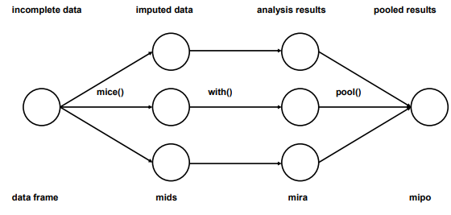

### 2.3.1 Step 0

*Set imputation model*:

```r
ini <- mice(data=nhanes, maxit = 0, print = FALSE)
pred <- ini$pred
pred
```

```
##     age bmi hyp chl
## age   0   1   1   1
## bmi   1   0   1   1
## hyp   1   1   0   1
## chl   1   1   1   0
```

```r
pred[,"hyp"] <- 0
# if you believe 'hyp' should not be a predictor in the inputation model
pred
```

```
##     age bmi hyp chl
## age   0   1   0   1
## bmi   1   0   0   1
## hyp   1   1   0   1
## chl   1   1   0   0
```

```r
# for CHL: bmi and age used to predict chl (hyp is not a predictor)
# for HYP: bmi, age and chl used to predict hyp (hyp is not a predictor)
```

*Set imputation method*:

```r
meth <- ini$meth
meth
```

```
##   age   bmi   hyp   chl
##    "" "pmm" "pmm" "pmm"
```

```r
# pmm is generally a good method,
# but let's see how to work with other methods
# just as an example.
# Specifying imputation method:
meth["bmi"] <- "mean"
# for BMI: no predictor used in mean method
# (only average of observed bmi)
meth["chl"] <- "norm.predict"
meth["hyp"] <- "norm.nob"
meth
```

```
##            age            bmi            hyp            chl
##             ""         "mean"     "norm.nob" "norm.predict"
```

*Set imputation model based on correlation alone*:

```r
predictor.selection <- quickpred(nhanes,
                                 mincor=0.1, # absolute correlation
                                 minpuc=0.1) # proportion of usable cases
predictor.selection
```

```
##     age bmi hyp chl
## age   0   0   0   0
## bmi   1   0   1   1
## hyp   1   0   0   1
## chl   1   1   1   0
```